# Análise de associação entre as variáveis sociodemográficas e as mortes por psicoativos

2024-10-28

# Características da base de dados

Para o estudo, considerou-se dados de 229575 notificações da base de dados do SIM (Sistema de Informação sobre Mortalidade), sendo que 6296 são do Espírito Santo. Todos os registros são de mortes relacionadas (indiretamente ou diretamente) ao uso de psicoativos.

Na Tabela abaixo estão os nomes dos registros (variáveis) considerados e sua descrição.

Descrição das variáveis

| Variável | Descrição |
| --- | --- |
| CAUSABAS | Causa básica da declaração de óbito |
| RACACOR | Cor de pele considerada |
| SEXO | Sexo |
| ESTCIV | Estado Civil |
| ESC | Escolaridade |
| OCUP | Ocupação |
| LOCOCOR | Local de óbito |
| IDADE2 | Idade em que a pessoa faleceu |

Devido a grande quantidade de CIDs foi necessário juntá-las em grupos. Na Tabela 2 estão as descrições desses grupos. Eles foram definidos de acordo com os agrupamentos da lista do departamento de informação do SUS (DATASUS) que descreve por completo a CID-10. A lista pode ser acessada em: http://www2.datasus.gov.br/cid10/V2008/WebHelp/listacateg.htm.

Descrição dos agrupamentos de CIDs

| Grupo | Descrição |
| --- | --- |
| F100-F199 e F55 | Transtornos mentais e comportamentais |
| G312, G620-G622 e G721-G722 | Doenças do sistema nervoso |
| I426-I427 e I952 | Doenças do aparelho circulatório |
| J662 e J702-J704 | Doenças do aparelho respiratório |
| K292, K700-K709 e K860 | Doenças do aparelho digestivo |
| M342 | Esclerose sistêmica induzida por droga e substâncias químicas |
| N140-N142 | Afecções tubulares e túbulo-intersticiais induzidas por drogas ou metais pesados |
| P042-P044, P961 e Q860 | Feto/recém-nascido afetados por substâncias usadas pela mãe na gravidez |
| R780-R785 | Presença de drogas e de outras substâncias normalmente não encontradas no sangue |
| X400-X469 | Intoxicação acidental por e exposição a substâncias nocivas |
| X600-X699 | Auto-intoxicação por substâncias nocivas |
| X850-X859 | Agressões |
| Y100-Y169 | Intoxicação por e exposição a substâncias cuja intenção não é determinada |
| Y450-Y579 | Efeitos adversos de drogas, medicamentos e substâncias biológicas usadas com finalidade terapêutica |

Vale ressaltar que foram desconsideradas as CIDs X45.0-X46.9, pois as mesmas representam casos de intoxicação acidental relacionados a substâncias usadas em pinturas, serviços gerais e área indústrial, ou seja, tais CIDs estão relacionadas a acidentes de trabalho. As CIDs X65-X66 servem para as mesmas substâncias, porém dessa vez quando foram usadas por vontade própria, essas sim foram contadas nas análises como psicoativos.

# Objetivos

Análisar a independência entre as variáveis sociodeomográficas e o número de mortes por psicoativos.

# Metodologia

Quando possível, foram contruídas tabelas de contingência relacionando cada grupo de CIDs com as variáveis sociodemográficas. Para testar a independência entre as variáveis sociodemográficas e as mortes relacionadas a um determinado grupo de CIDs, realizou-se o teste Qui-Quadrado de independência. O nível de confiança considerado foi de 5% ($p < 0.05$). Nos gráficos tipo mapa de calor as tonalidades mais escuras (cor azul) indicam baixas ou nenhuma ocorrência e as mais claras e fortes (cor amarela) indicam as maiores quantidades.

# Análises para o Espiríto Santo

## RACACOR

|  | Amarela | Branca | Indígena | Parda | Preta |
| --- | --- | --- | --- | --- | --- |
| (F100-F199) | 4 | 605 | 4 | 1216 | 368 |
| (G312, G621 e G721) | 0 | 13 | 0 | 21 | 5 |
| (I426 e I427) | 0 | 98 | 1 | 266 | 62 |
| (J703 e J704) | 0 | 0 | 0 | 2 | 0 |
| (K292, K700-K709 e K860) | 10 | 895 | 3 | 1276 | 359 |
| (N141 e N142) | 0 | 3 | 0 | 0 | 0 |
| (P042-P044) | 0 | 2 | 0 | 13 | 0 |
| (X400-X459) | 0 | 28 | 0 | 117 | 11 |
| (X600-X699) | 0 | 75 | 1 | 118 | 13 |
| (X850) | 0 | 0 | 0 | 0 | 0 |
| (Y100-Y159) | 0 | 10 | 0 | 31 | 6 |
| (Y471, 494, Y499 e Y579) | 0 | 3 | 0 | 4 | 1 |

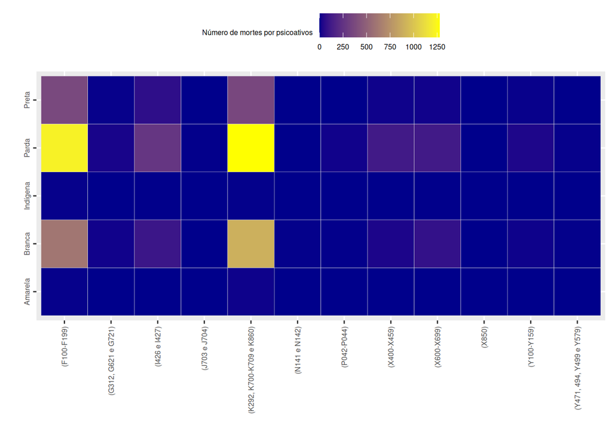

## SEXO

A tabela abaixo traz indicativos de que os homens morrem mais do que as mulheres em grande parte dos casos.

|  | Feminino | Masculino |
| --- | --- | --- |
| (F100-F199) | 348 | 2049 |
| (G312, G621 e G721) | 2 | 39 |
| (I426 e I427) | 33 | 407 |
| (J703 e J704) | 1 | 2 |
| (K292, K700-K709 e K860) | 425 | 2438 |
| (N141 e N142) | 2 | 1 |
| (P042-P044) | 7 | 11 |
| (X400-X459) | 63 | 111 |
| (X600-X699) | 125 | 100 |
| (X850) | 0 | 1 |
| (Y100-Y159) | 18 | 32 |
| (Y471, 494, Y499 e Y579) | 3 | 7 |

Foi realizada uma análise da significância da associação entre o número de mortes por psicoativos e a variável SEXO. As mortes relacionadas com os grupos de CIDs (J703 e J704), (N141 e N142), (P042-P044), (X600-X699), (Y100-Y159) e (Y100-Y159) não apresentaram associação com a varíavel SEXO. As demais CIDs se apresentaram estatísticamente associadas a variável socioecômica em questão ($p < 0.05$), sugerindo assim que em grande parte das vezes o sexo dos indivíduos tenha associação estatística com seu falecimento.

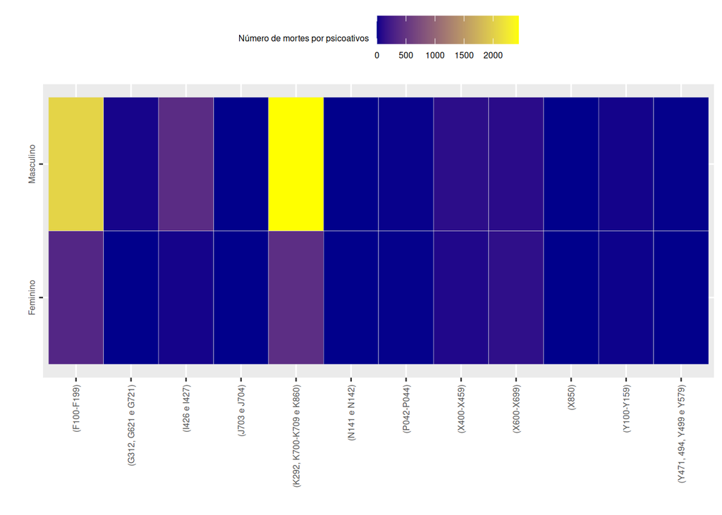

## ESTCIV

Nesse caso, percebe-se que os solteiros são os que mais morreram. Outro fato a se destacar e que para as CIDs (F100-F199) e (K292, K700-K709 e K860) houve um número elevado de morte dos casados.

|  | Casado | Separado judicialmente | Solteiro | União consensual | Viúvo |
| --- | --- | --- | --- | --- | --- |
| (F100-F199) | 502 | 251 | 1101 | 36 | 154 |
| (G312, G621 e G721) | 13 | 2 | 13 | 3 | 3 |
| (I426 e I427) | 86 | 44 | 236 | 1 | 22 |
| (J703 e J704) | 0 | 0 | 3 | 0 | 0 |
| (K292, K700-K709 e K860) | 786 | 315 | 917 | 90 | 166 |
| (N141 e N142) | 0 | 2 | 0 | 0 | 1 |
| (P042-P044) | 0 | 0 | 0 | 0 | 0 |
| (X400-X459) | 27 | 8 | 109 | 0 | 8 |
| (X600-X699) | 59 | 20 | 93 | 5 | 8 |
| (X850) | 0 | 0 | 0 | 0 | 0 |
| (Y100-Y159) | 9 | 2 | 22 | 2 | 1 |
| (Y471, 494, Y499 e Y579) | 1 | 0 | 3 | 1 | 1 |

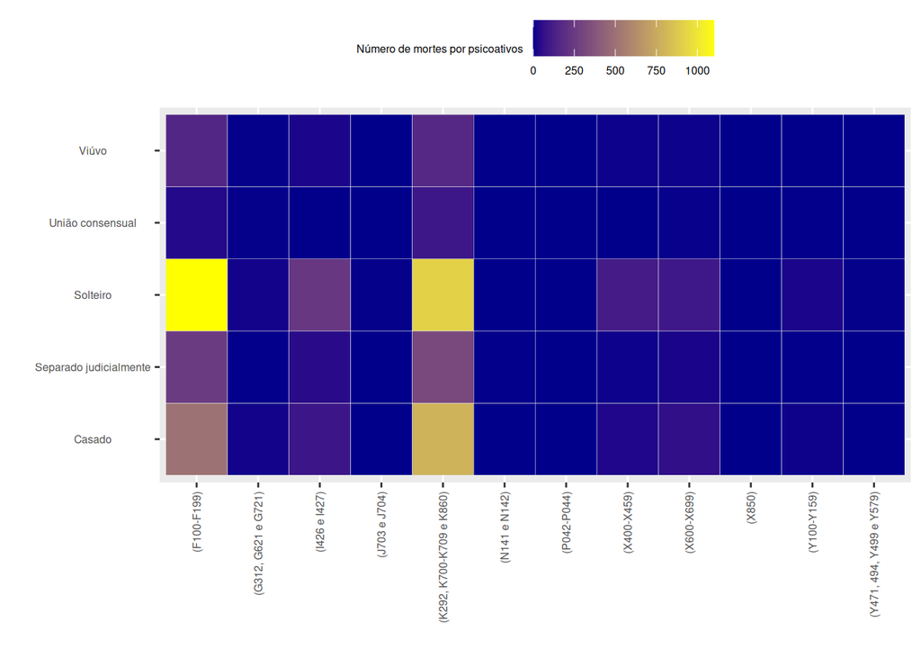

## ESC

Para a escolaridade, repara-se que o que menos apresentou mortes foi a classe 12 anos ou mais.

|  | 1 a 3 anos | 12 anos ou mais | 4 a 7 anos | 8 a 11 anos | Nenhuma |
| --- | --- | --- | --- | --- | --- |
| (F100-F199) | 541 | 35 | 589 | 341 | 315 |
| (G312, G621 e G721) | 10 | 1 | 6 | 6 | 7 |
| (I426 e I427) | 126 | 5 | 133 | 75 | 61 |
| (J703 e J704) | 2 | 0 | 1 | 0 | 0 |
| (K292, K700-K709 e K860) | 560 | 57 | 574 | 360 | 208 |
| (N141 e N142) | 0 | 0 | 0 | 1 | 0 |
| (P042-P044) | 0 | 0 | 0 | 0 | 0 |
| (X400-X459) | 10 | 7 | 25 | 29 | 7 |
| (X600-X699) | 26 | 23 | 21 | 37 | 7 |
| (X850) | 0 | 0 | 0 | 0 | 0 |
| (Y100-Y159) | 4 | 2 | 7 | 10 | 0 |
| (Y471, 494, Y499 e Y579) | 0 | 1 | 1 | 2 | 1 |

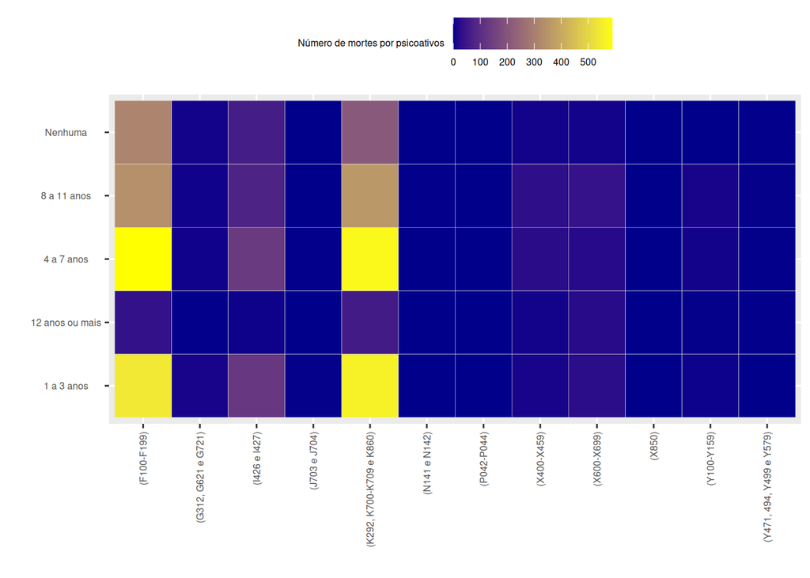

## LOCOCOR

Note pela tabela abaixo que a grande partes das mortes ocorreram ou em domicílio ou no hospital.

|  | Domicílio | Hospital | Outro estabelecimento de saúde | Outros | Via pública |
| --- | --- | --- | --- | --- | --- |
| (F100-F199) | 989 | 968 | 257 | 101 | 75 |
| (G312, G621 e G721) | 12 | 28 | 1 | 0 | 0 |
| (I426 e I427) | 225 | 111 | 58 | 23 | 24 |
| (J703 e J704) | 1 | 2 | 0 | 0 | 0 |
| (K292, K700-K709 e K860) | 501 | 2153 | 131 | 46 | 27 |
| (N141 e N142) | 1 | 2 | 0 | 0 | 0 |
| (P042-P044) | 0 | 18 | 0 | 0 | 0 |
| (X400-X459) | 53 | 64 | 24 | 22 | 8 |
| (X600-X699) | 63 | 126 | 19 | 10 | 7 |
| (X850) | 0 | 1 | 0 | 0 | 0 |
| (Y100-Y159) | 20 | 15 | 8 | 4 | 3 |
| (Y471, 494, Y499 e Y579) | 0 | 8 | 1 | 1 | 0 |

Foi realizada uma análise da significância da associação entre o número de mortes por psicoativos e a variável LOCOCOR. As mortes relacionadas com os grupos de CIDs (J703 e J704), (N141 e N142) e (Y471, 494, Y499 e Y579) não apresentaram associação com a varíavel LOCOCOR. As demais CIDs se apresentaram estatísticamente associadas ao local de morte ($p < 0.05$), sugerindo assim que na maioria dos casos o local em que o indivíduo estava pode ter influênciado na sua morte.

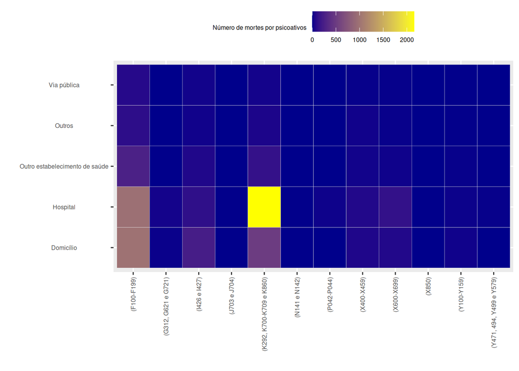

## IDADE2

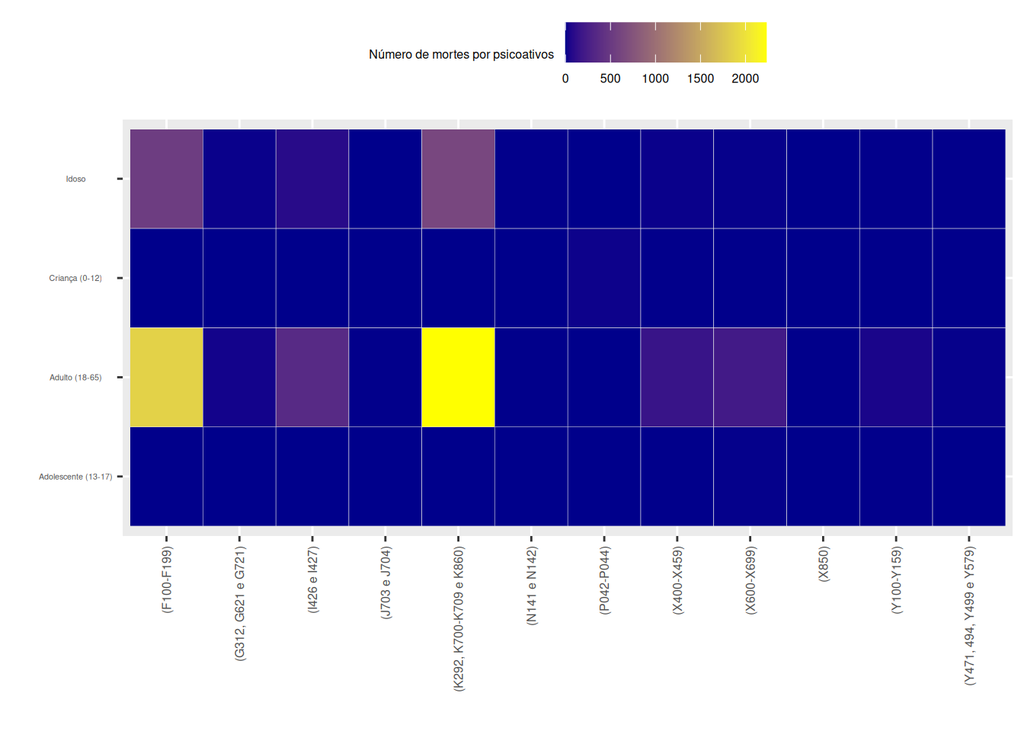

# Análises para o Brasil

## RACACOR

Na tabela de contingência abaixo, repare as pessoas classificadas como “pardas” e “brancas” foram as que mais morreram independentemente das categorias.

|  | Amarela | Branca | Indígena | Parda | Preta |
| --- | --- | --- | --- | --- | --- |
| (F100-F199 e F55) | 297 | 33671 | 386 | 46889 | 12388 |
| (G312, G620-G622 e G721-G722) | 4 | 755 | 7 | 856 | 257 |
| (I426-I427 e I952) | 4 | 989 | 9 | 1695 | 421 |
| (J662 e J702-J704) | 0 | 41 | 0 | 29 | 4 |
| (K292, K700-K709 e K860) | 385 | 42631 | 362 | 49820 | 10416 |
| (M342) | 0 | 5 | 0 | 7 | 0 |
| (N140-N142) | 2 | 48 | 0 | 31 | 8 |
| (P042-P044, P961 e Q860) | 1 | 209 | 6 | 258 | 27 |
| (R780-R785) | 0 | 5 | 0 | 5 | 2 |
| (X400-X469) | 14 | 1832 | 10 | 2929 | 551 |
| (X600-X699) | 40 | 4375 | 55 | 3570 | 581 |
| (X850-X859) | 0 | 41 | 0 | 49 | 6 |
| (Y100-Y169) | 12 | 1447 | 12 | 1592 | 335 |
| (Y450-Y579) | 5 | 296 | 0 | 171 | 66 |

Foi realizada uma análise da significância da associação entre o número de mortes por psicoativos e a variável RACACOR. As mortes relacionadas com os grupos de CIDs (M342) e (R780-R785) não apresentaram associação com a varíavel RACACOR. As demais CIDs se apresentaram estatísticamente associadas a cor de pele ($p < 0.05$), sugerindo assim que em grande parte das vezes a cor dos indivíduos pode ter influenciado em sua morte.

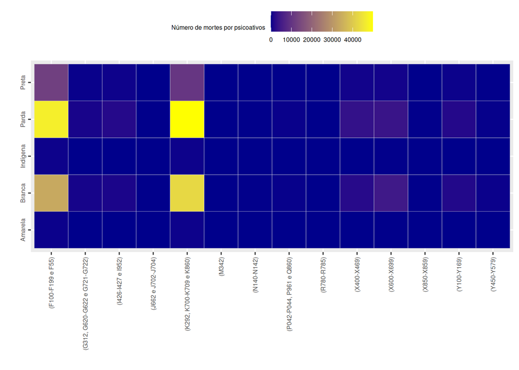

## SEXO

A tabela abaixo traz indicativos de que os homens morrem mais do que as mulheres em grande parte dos casos. No caso das mortes relacionadas com o grupo (Y450-Y579), morreram mais mulheres do que homens.

|  | Feminino | Masculino |
| --- | --- | --- |
| (F100-F199 e F55) | 13745 | 82879 |
| (G312, G620-G622 e G721-G722) | 211 | 1751 |
| (I426-I427 e I952) | 334 | 2856 |
| (J662 e J702-J704) | 25 | 50 |
| (K292, K700-K709 e K860) | 12387 | 94796 |
| (M342) | 3 | 9 |
| (N140-N142) | 42 | 50 |
| (P042-P044, P961 e Q860) | 218 | 325 |
| (R780-R785) | 4 | 8 |
| (X400-X469) | 1447 | 3976 |
| (X600-X699) | 4207 | 4625 |
| (X850-X859) | 22 | 77 |
| (Y100-Y169) | 1081 | 2406 |
| (Y450-Y579) | 314 | 245 |

Foi realizada uma análise da significância da associação entre o número de mortes por psicoativos e a variável SEXO. As mortes relacionadas com os grupos de CIDs (R780-R785), (N140-N142) e (M342) não apresentaram associação com a varíavel SEXO. As demais CIDs se apresentaram estatísticamente associadas a variável socioecômica em questão ($p < 0.05$).

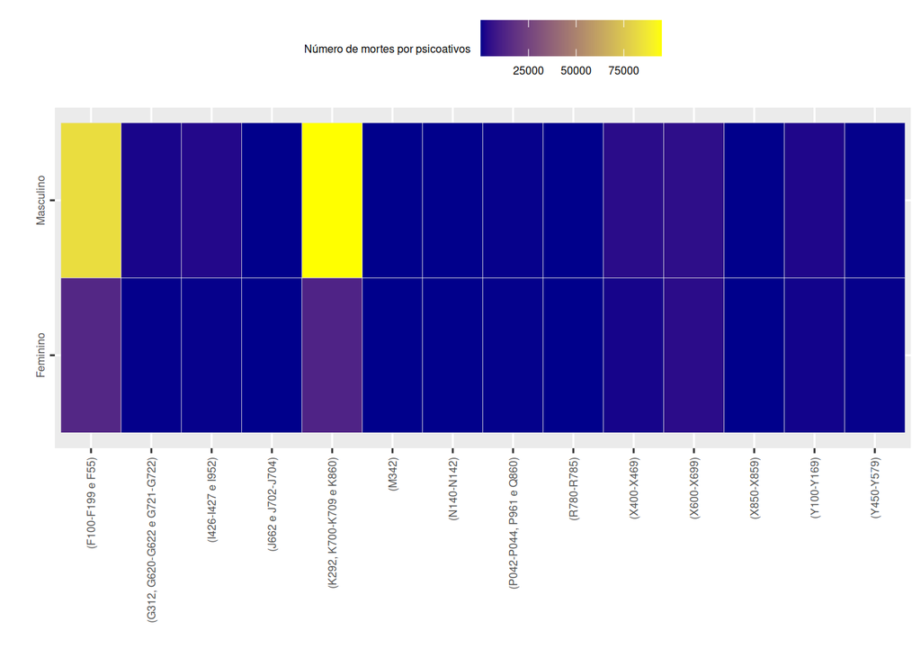

## ESTCIV

Nesse caso, percebe-se que os solteiros são os que mais morreram. Outro fato a se destacar e que para as CIDs (F100-F199 e F55) e (K292, K700-K709 e K860) houve um número elevado de morte dos casados.

|  | Casado | Separado judicialmente | Solteiro | União consensual | Viúvo |
| --- | --- | --- | --- | --- | --- |
| (F100-F199 e F55) | 20161 | 9051 | 46752 | 3845 | 7388 |
| (G312, G620-G622 e G721-G722) | 480 | 211 | 853 | 88 | 127 |
| (I426-I427 e I952) | 722 | 289 | 1603 | 138 | 182 |
| (J662 e J702-J704) | 24 | 4 | 29 | 2 | 7 |
| (K292, K700-K709 e K860) | 30693 | 11848 | 43771 | 5002 | 6552 |
| (M342) | 8 | 2 | 2 | 0 | 0 |
| (N140-N142) | 39 | 9 | 13 | 2 | 24 |
| (P042-P044, P961 e Q860) | 1 | 0 | 1 | 0 | 0 |
| (R780-R785) | 2 | 1 | 7 | 1 | 0 |
| (X400-X469) | 605 | 213 | 3932 | 140 | 183 |
| (X600-X699) | 1901 | 806 | 4718 | 424 | 320 |
| (X850-X859) | 15 | 2 | 56 | 3 | 3 |
| (Y100-Y169) | 688 | 259 | 1902 | 154 | 190 |
| (Y450-Y579) | 158 | 48 | 197 | 13 | 96 |

Foi realizada uma análise da significância da associação entre o número de mortes por psicoativos e a variável ESTCIV. Somente as mortes relacionadas com os grupos de CIDs (R780-R785) e (P042-P044, P961 e Q860) não apresentaram associação com a varíavel ESTCIV. As demais CIDs se apresentaram estatísticamente associadas a variável socioecômica em questão ($p < 0.05$).

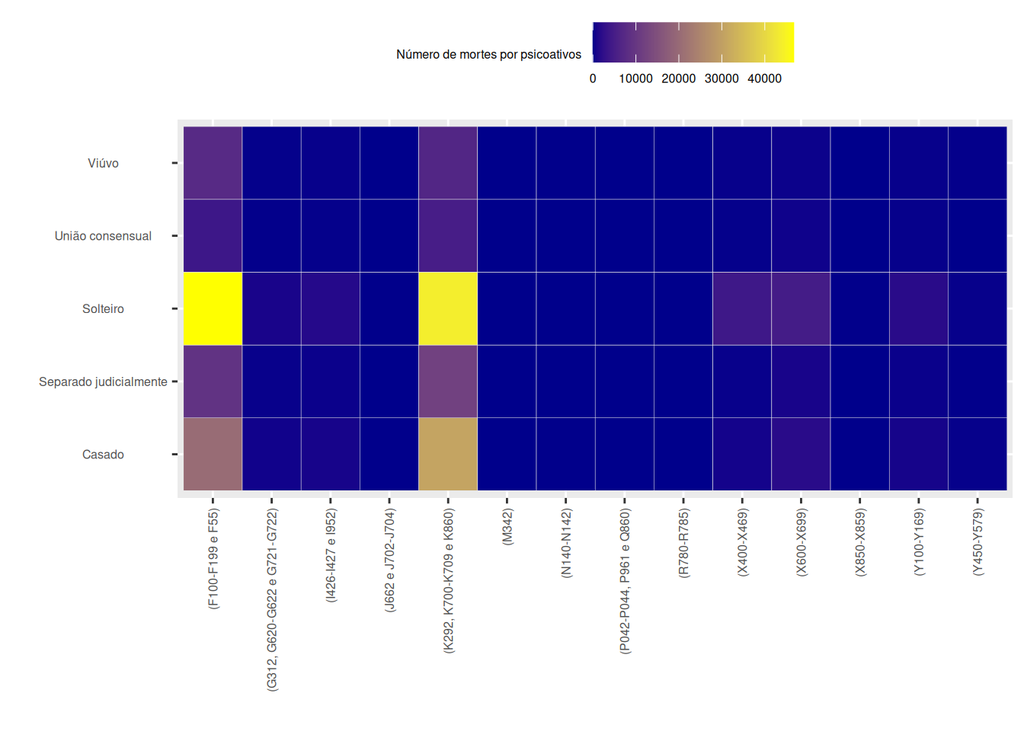

## ESC

Para a escolaridade, repara-se que o que menos apresentou mortes foi a classe 12 anos ou mais. Além disso a maioria das mortes estão relacionadas com o grupo (K292, K700-K709 e K860).

|  | 1 a 3 anos | 12 anos ou mais | 4 a 7 anos | 8 a 11 anos | Nenhuma |
| --- | --- | --- | --- | --- | --- |
| (F100-F199 e F55) | 23472 | 1873 | 23824 | 12822 | 16677 |
| (G312, G620-G622 e G721-G722) | 531 | 44 | 493 | 294 | 233 |
| (I426-I427 e I952) | 878 | 66 | 871 | 493 | 428 |
| (J662 e J702-J704) | 14 | 9 | 10 | 19 | 8 |
| (K292, K700-K709 e K860) | 25830 | 3236 | 27276 | 17983 | 13423 |
| (M342) | 1 | 3 | 0 | 3 | 4 |
| (N140-N142) | 16 | 10 | 24 | 14 | 15 |
| (P042-P044, P961 e Q860) | 0 | 0 | 0 | 0 | 2 |
| (R780-R785) | 0 | 0 | 5 | 3 | 1 |
| (X400-X469) | 768 | 344 | 1997 | 1532 | 147 |
| (X600-X699) | 1006 | 1239 | 1885 | 2639 | 394 |
| (X850-X859) | 14 | 4 | 26 | 16 | 4 |
| (Y100-Y169) | 576 | 239 | 874 | 894 | 289 |
| (Y450-Y579) | 93 | 54 | 110 | 131 | 53 |

As mortes relacionadas com os grupos de CIDs (R780-R785), (N140-N142), (M342) e (J662 e J702-J704) não apresentaram associação com a varíavel ESC, as demais apresentaram.

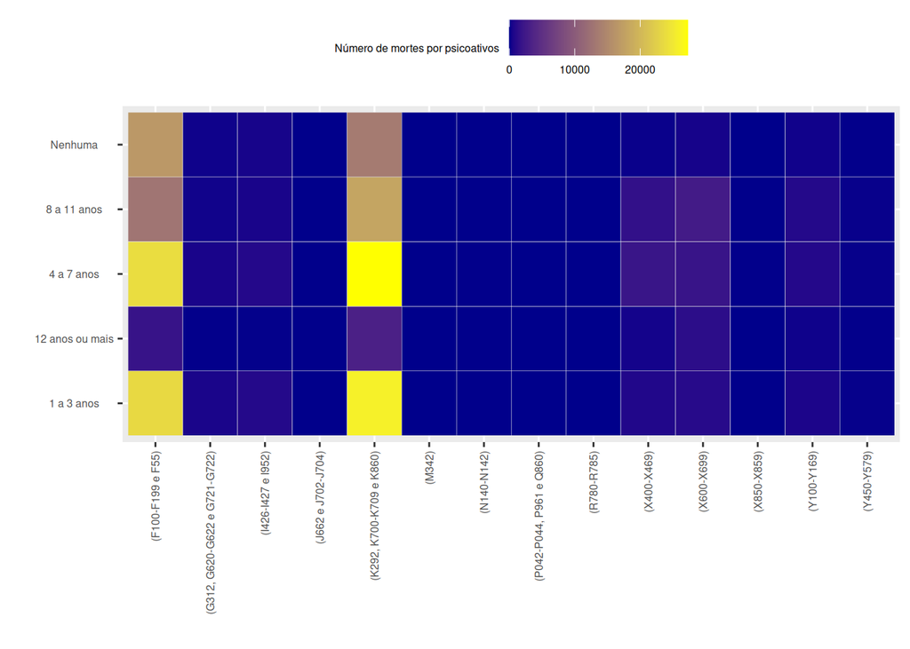

## LOCOCOR

Note pela tabela abaixo que a grande partes das mortes ocorreram ou em domicílio ou no hospital. O número 6 é referente a aldeia indígena.

|  | 6 | Domicílio | Hospital | Outro estabelecimento de saúde | Outros | Via pública |
| --- | --- | --- | --- | --- | --- | --- |
| (F100-F199 e F55) | 4 | 44988 | 36309 | 7622 | 4064 | 3533 |
| (G312, G620-G622 e G721-G722) | 0 | 413 | 1344 | 139 | 45 | 20 |
| (I426-I427 e I952) | 0 | 1291 | 1426 | 245 | 130 | 98 |
| (J662 e J702-J704) | 0 | 13 | 50 | 10 | 0 | 2 |
| (K292, K700-K709 e K860) | 0 | 20920 | 77322 | 6606 | 1281 | 1014 |
| (M342) | 0 | 1 | 10 | 1 | 0 | 0 |
| (N140-N142) | 0 | 10 | 73 | 6 | 3 | 0 |
| (P042-P044, P961 e Q860) | 0 | 25 | 499 | 10 | 6 | 5 |
| (R780-R785) | 0 | 3 | 4 | 1 | 2 | 2 |
| (X400-X469) | 0 | 972 | 2767 | 854 | 405 | 418 |
| (X600-X699) | 1 | 2231 | 5019 | 751 | 622 | 197 |
| (X850-X859) | 0 | 16 | 37 | 2 | 17 | 26 |
| (Y100-Y169) | 0 | 848 | 1831 | 393 | 248 | 166 |
| (Y450-Y579) | 0 | 31 | 439 | 65 | 16 | 8 |

Foi realizada uma análise da significância da associação entre o número de mortes por psicoativos e a variável LOCOCOR. Somente as mortes relacionadas com o grupo de CIDs (R780-R785) não apresentaram associação com a varíavel LOCOCOR. As demais CIDs se apresentaram estatísticamente associadas ao local de morte ($p < 0.05$).

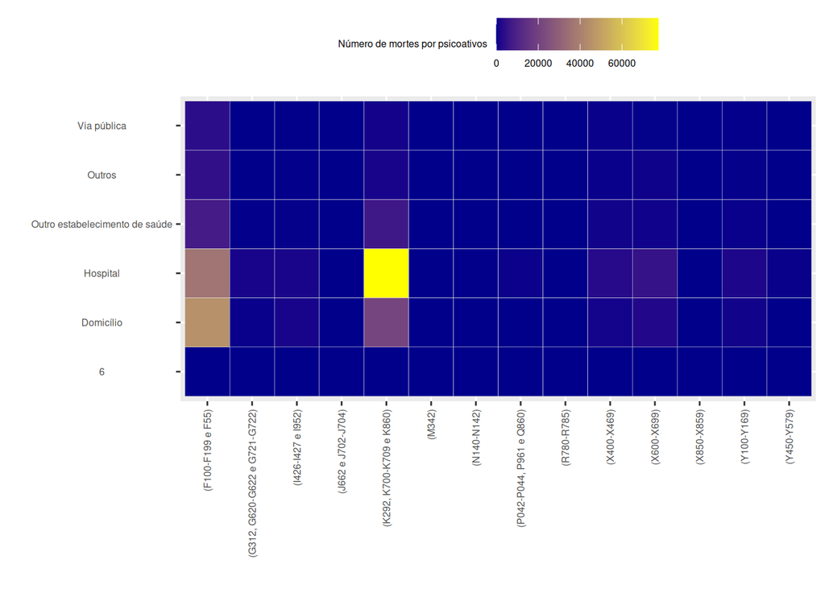

## IDADE2

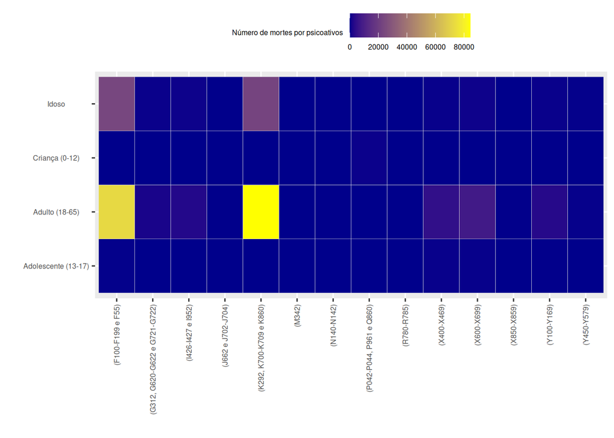

## OBSERVAÇÕES

Além dessa análise, também foi realizada uma análise com agrupamentos que consideravam tipos de droga (maconha, cocaína, álcool e etc), mas devido ao fato de que muitas CIDs não especificam o tipo de droga, englobam diversas drogas ou ainda descrevem casos bem específicos, não se conseguiu fazer bons agrupamentos. Sendo assim, grande parte dos casos acaba se concentrando em grupos mais gerais, que não traziam muita informação. Nesse caso, para se fazer um bom agrupamento por tipos de droga seria necessário alguém com um conhecimento mais específico para determinar qual droga que uma determinada CID poderia estar mais relacionada e assim auxiliar na construção dos agrupamentos.